# Plotting in R with ggplot2

# Import data to plot

We are going to plot some data about cars that is contained in the `cars93.csv` file. First we import the data.

```r
cars <- read.csv("cars93.csv")
```

Let’s have a quick look at the data first.

```r
head(cars)
```

```
##   manufacturer   model    type cityMPG enginesize weight fuelEco
## 1        Acura Integra   Small      25        1.8   2705    Good
## 2        Acura  Legend Midsize      18        3.2   3560    Poor
## 3         Audi      90 Compact      20        2.8   3375    Poor
## 4         Audi     100 Midsize      19        2.8   3405    Poor
## 5          BMW    535i Midsize      22        3.5   3640    Good
## 6        Buick Century Midsize      22        2.2   2880    Good
```

```r
summary(cars)
```

```
##  manufacturer          model               type
##  Length:93          Length:93          Length:93
##  Class :character   Class :character   Class :character
##  Mode  :character   Mode  :character   Mode  :character
##
##
##
##     cityMPG        enginesize        weight       fuelEco
##  Min.   :15.00   Min.   :1.000   Min.   :1695   Length:93
##  1st Qu.:18.00   1st Qu.:1.800   1st Qu.:2620   Class :character
##  Median :21.00   Median :2.400   Median :3040   Mode  :character
##  Mean   :22.37   Mean   :2.668   Mean   :3073
##  3rd Qu.:25.00   3rd Qu.:3.300   3rd Qu.:3525
##  Max.   :46.00   Max.   :5.700   Max.   :4105
```

# Install and load ggplot2

The `ggplot2` package is in the `tidyverse`, which we have already installed. If you need to install it on another computer without installing the whole tidyverse, you will know form last lesson how to do this.

```r
install.packages("ggplot2")
```

Remember, when you are using ggplot2 (or any package) in any R session, you have to tell R to load the ggplot2 library before you can access its commands. You have to do this every time you open a new session of R.

```r
library(ggplot2)
```

# Plot types

## Two continuous variables (scatterplot)

The basic elements of a command in ggplot2 are data `cars`, aesthetics `aes(x,y)`, and plot type `geom_point()`.

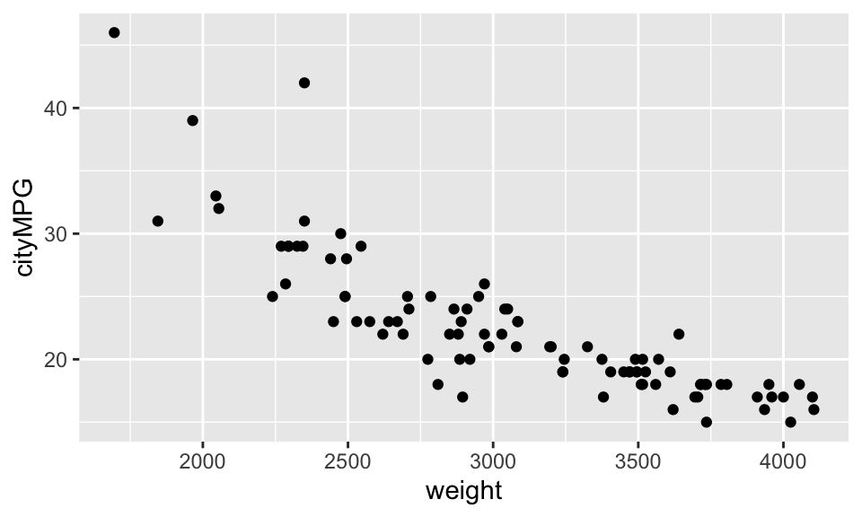

```r
ggplot(cars, aes(x = weight, y = cityMPG)) +
  geom_point()
```

Can you see your plot? Did you get an error `Error in plot.new() : figure margins too large`? These both happen because the plots come up in a plane on the left that you may have squished is you have only one screen. Time to un-squish the left plane.

Wanna be fancy? Add a trend line with `+geom_smooth()`.

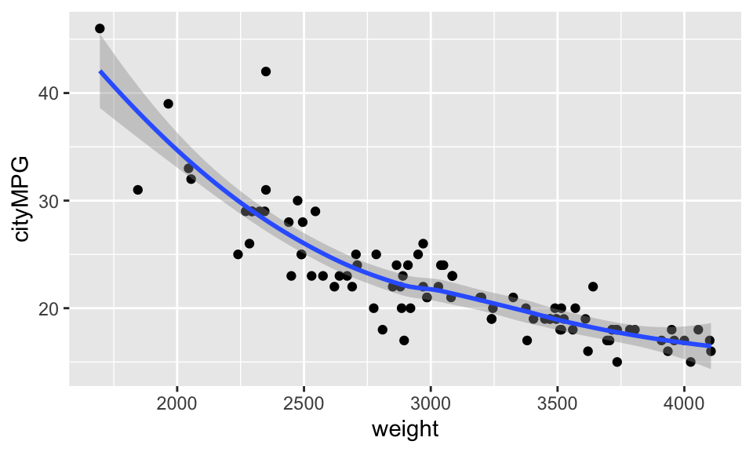

```r
ggplot(cars, aes(weight, cityMPG)) +
  geom_point() +
  geom_smooth()
```

I have not used `x=weight` and `y=cityMPG` this time, if I don’t specify, then `ggplot` will assume the first variable is the `x` variable, and the second is `y`,

What if we want different colours by car type? All you go is add a `color =` statement inside `aes()`.

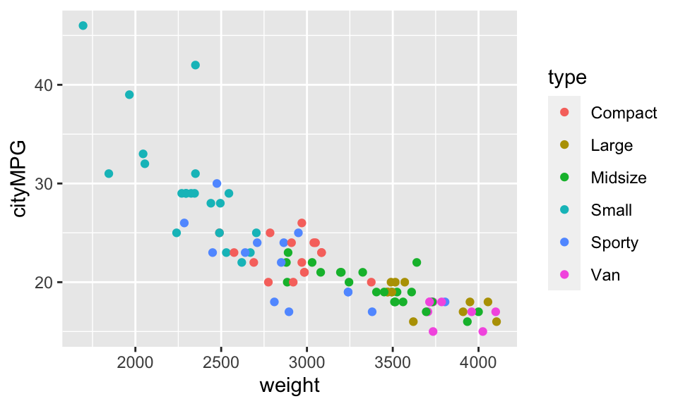

```r
ggplot(cars, aes(weight, cityMPG, color = type)) +
  geom_point()
```

We can add smooth lines with `geom_smooth()`, but it’s a bit messy here, so I will add straight lines with `method="lm"`. Also, I don’t want shading, so I will add `se=FALSE`.

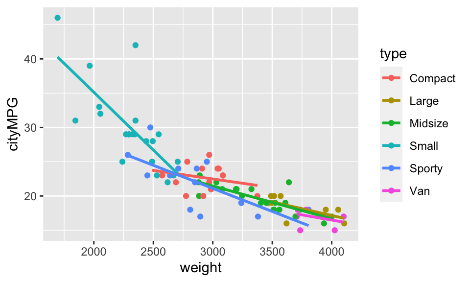

```r
ggplot(cars, aes(weight, cityMPG,color=type)) +
  geom_point() +
  geom_smooth(se=FALSE,method="lm")
```

## One continuous variable (histogram or boxplot)

Histograms are easy, we just need one variable inside `aes()`, if we want just one histogram.

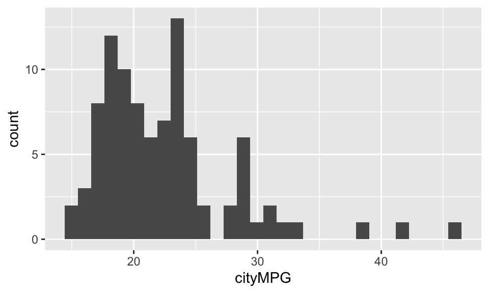

```r
ggplot(cars, aes(x=cityMPG)) +
  geom_histogram()
```

Change to boxplot by changing the plot type and specifying `y` variable.

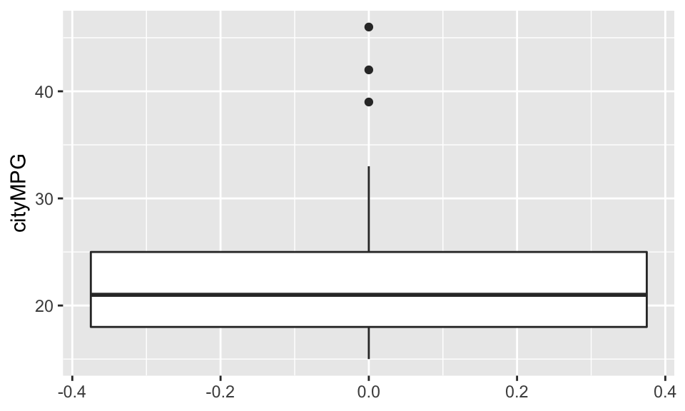

```r
ggplot(cars, aes(y=cityMPG)) +
  geom_boxplot()
```

## One continuous variable and one categorical variable (boxplot)

We can do box plots by type by setting type as the `x` variable.

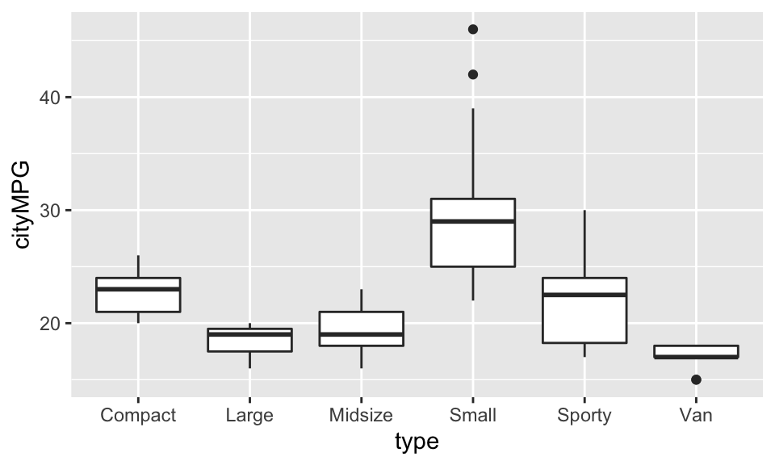

```r
ggplot(cars, aes(x=type,y=cityMPG)) +
  geom_boxplot()
```

And add colours by specifying either color (as before) or fill.

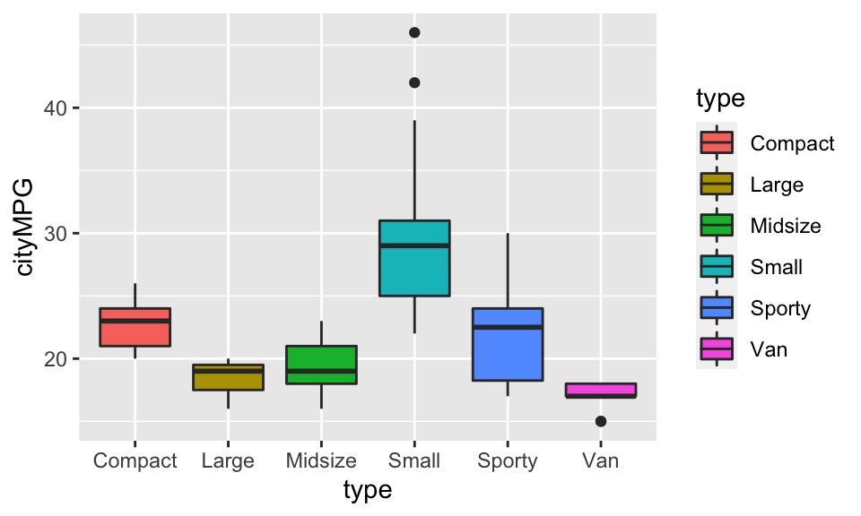

```r
ggplot(cars, aes(type,cityMPG,fill=type)) +
  geom_boxplot()
```

## One categorical variable (barplot)

To plot one categorical variable `type` we can make a barplot with `geom_bar()`.

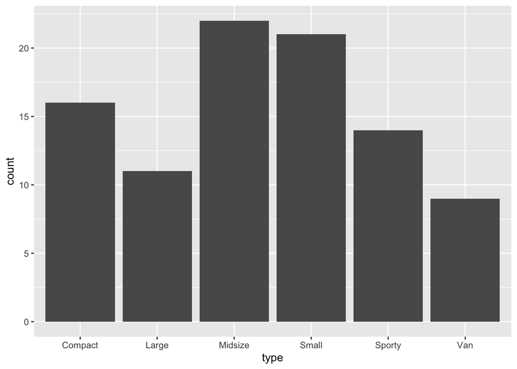

```r
ggplot(cars, aes(type)) +
    geom_bar()
```

You can make the categories different colours with the `fill=` option using the same variable again.

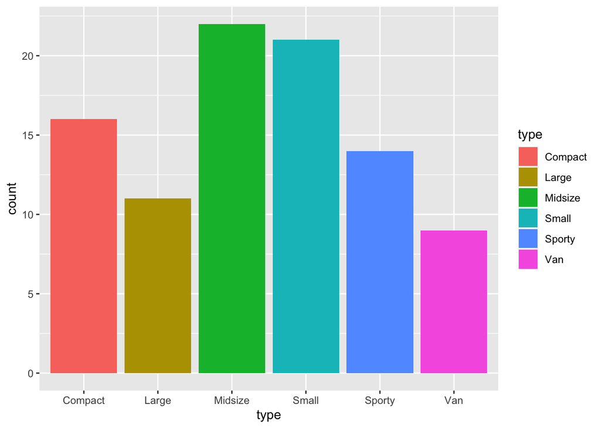

```r
ggplot(cars, aes(type,fill=type)) +
    geom_bar()
```

## Two categorical variables (barplot)

We have two options for bar plots for two categorical variable. The defaults is a stacked bar plot. You just add the second variable as the `fill=` option.

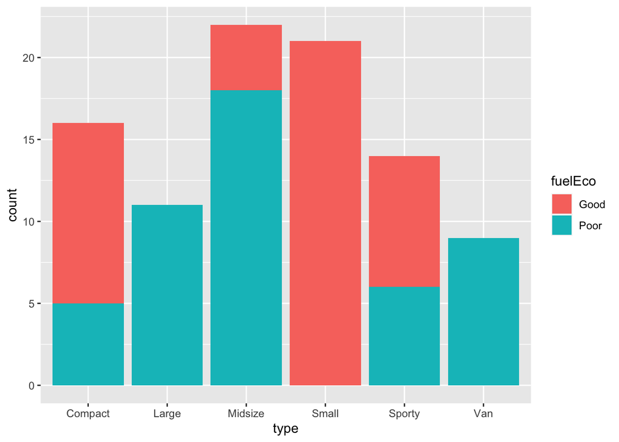

```r
ggplot(cars, aes(type,fill=fuelEco)) +
    geom_bar()
```

If you prefer a side by side bar chart, you just add the option `position = "dodge"`.

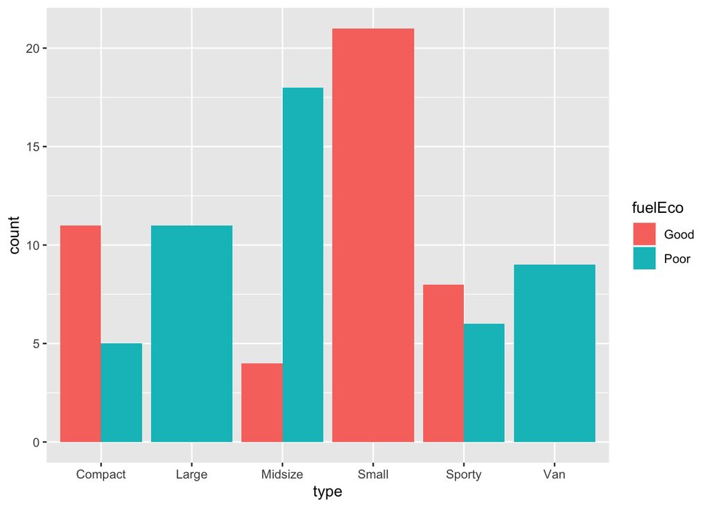

```r
ggplot(cars, aes(type,fill=fuelEco)) +
    geom_bar(position = "dodge")
```

# Customisation

## Labels

You can change the default x and y labels with `xlab()` and `ylab()`, and add a title with `ggtitle()`. This is demonstrated on the scatterplot from earlier.

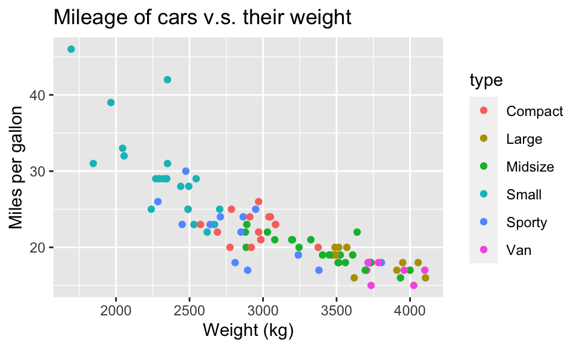

```r
ggplot(cars, aes(weight, cityMPG,color=type)) +
  geom_point() +
  ylab("Miles per gallon") +
  xlab("Weight (kg)") +
  ggtitle("Mileage of cars v.s. their weight")
```

## Themes

Themes let you easily change the look of your graph with one simple function. There are lots of themes available, the most commonly used are `theme_bw()` and `theme_classic()`.

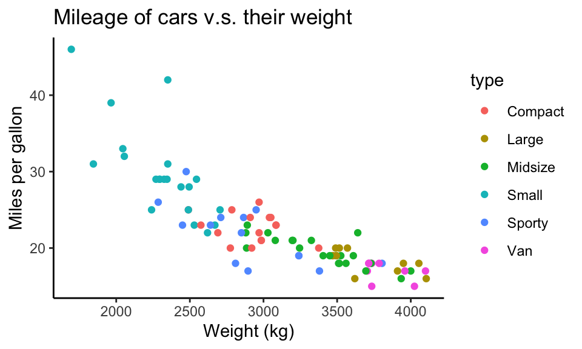

```r
ggplot(cars, aes(weight, cityMPG,color=type)) +
  geom_point() +
  ylab("Miles per gallon") +
  xlab("Weight (kg)") +
  ggtitle("Mileage of cars v.s. their weight") +
  theme_classic()
```

# Challenges

We will use the `CO2` data, which is stored in R and can be accessed by typing `CO2` (into your console), no need to import. Make sure all of your plots have appropriate titles and axis labels. Use `ggplot2` for this challenge.

1. How many variables are in the CO2 data set and what kinds are they?

Hint:

```r
str(CO2)
```

2. Create a histogram of the variable `uptake`.
3. Create a boxplot of `uptake` by `Treatment`, with different fills for each treatment.
4. Create a scatter plot of `uptake` by `conc`, with different colours and symbols by Treatment.
5. Add a smooth line to the previous plot with `geom_smooth()` to better see the patterns.

Make sure the script file you have explains what each line of code does with comments and save it in your project directory.

# Resources

We have covered the basic functionality of `ggplot2`, but there are lots of bells and whistles available. A good place to find out more about is the [cheatsheet](https://rstudio.com/wp-content/uploads/2016/11/ggplot2-cheatsheet-2.1.pdf). Also, have a look at the extensive [R graph gallery](https://www.r-graph-gallery.com/) for code for every possible plot you can imagine.

# Challenge solutions

1. How many variables are in the CO2 data set and what kinds are they?

```r
str(CO2)
```

There are 5 variables, two continuous, two factor and one ordinal factor.

2. Create a histogram of the variable `uptake`.

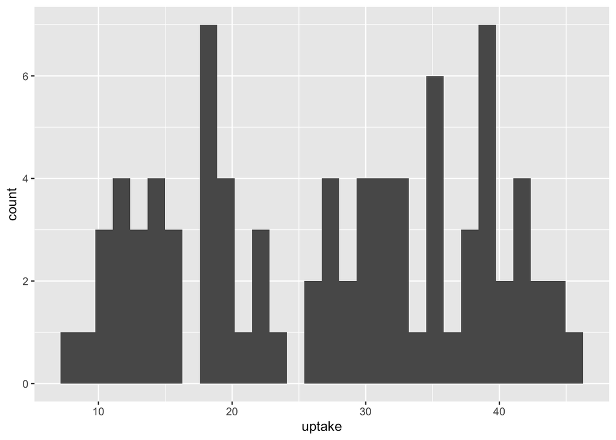

```r
p1<-ggplot(CO2,aes(x=uptake))+geom_histogram()
p1
```

3. Create a boxplot of `uptake` by `Treatment`, with different fills for each treatment.

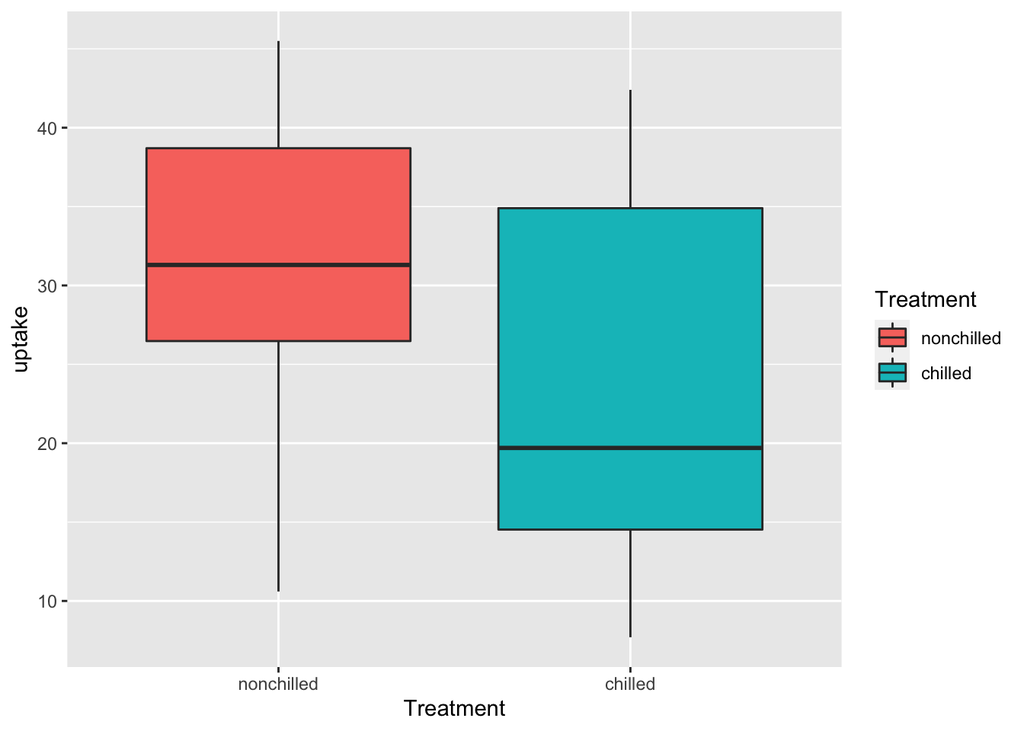

```r
p2<-ggplot(CO2,aes(x=Treatment,y=uptake,fill=Treatment))+geom_boxplot()
p2
```

4. Create a scatter plot of `uptake` by `conc`, with different colours and symbols by Treatment.

To figure out how to change symbols, have a look in the help file. Use the code below or type `geom_point` into the search field in the Help tab in RStudio.

```r
?geom_point
```

Looks like `shape` might be the right attribute to change, so I try that.

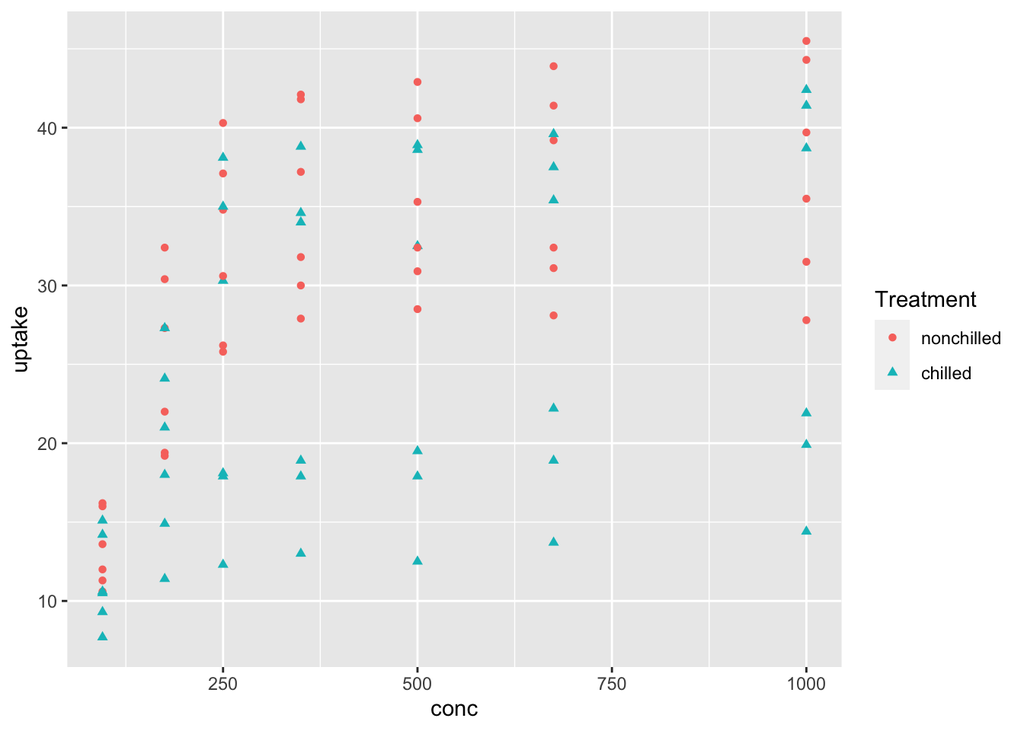

```r
p3<-ggplot(CO2,aes(x=conc,y=uptake,color=Treatment,shape=Treatment))+geom_point()
p3
```

5. Add a smooth line to the previous plot with `geom_smooth()` to better see the patterns.

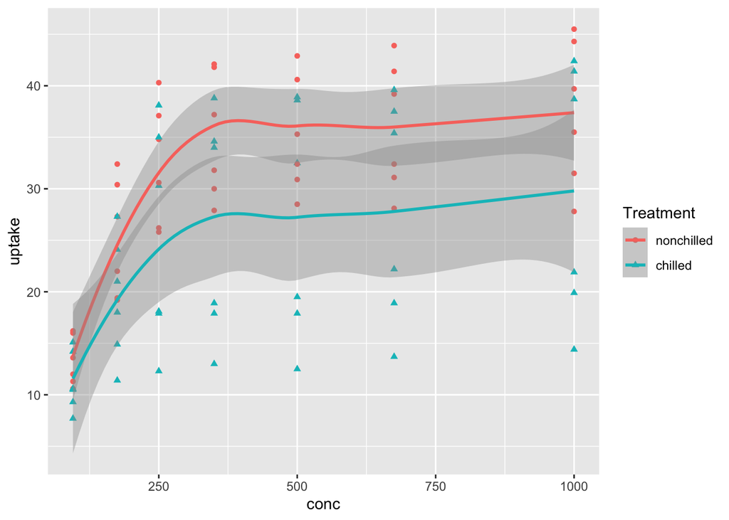

```r
p4<-p3+geom_smooth()
p4
```

**Authors**: Gordana Popovic & Mark Donoghoe

**Last updated**: 26 April, 2021